# Praktikum 6 - Pembuktian Teorema Statistika Ketakbiasan dan Selang Kepercayaan

Indri ramdani

2024-02-25

# Ketakbiasan Penduga $μ$ dan $σ^2$

$\bar{x}$ adalah penduga tak bias bagi $μ$, jika $E(\bar{x})=μ$

$s^2$ adalah penduga tak bias bagi $σ^2$, jika $E(s^2)=σ^2$

**Algoritma**

1. Tentukan sebaran yang akan digunakan
2. ulangi sebanyak k kali
   - Bangkitkan n buah data dari sebaran yang sudah ditentukan
   - Hitung nilai $\bar{x}$ dan $s^2$
3. Hitung rata-rata dari $\bar{x}$ dan $s^2$ , kemudian bandingan dengan $μ$ dan $σ^2$

**Aplikasi di R**

```r
n = 10
k = 1000 #ulangan
populasi = rnorm(100,25,sqrt(5)) # populasi menyebar normal
miu      = mean(populasi)
sigma2   = var(populasi)*(100-1)/100 #fungsi var di R adalah varian contoh sehingga perlu disesuaikan
sampel   = matrix(NA,k,n)
for (i in 1:k) sampel[i,] = sample (populasi,n)
xbar     = apply (sampel,1,mean)
s2       = apply(sampel,1,var)
E.xbar   = mean(xbar)
E.s2     = mean(s2)

hasil = data.frame( "."  = c("populasi","E(sampel)"),
                    mean   = c(miu, E.xbar),
                    varian = c(sigma2, E.s2))
hasil
```

| . | mean | varian |
| --- | --- | --- |
| populasi | 25.31758 | 4.874839 |
| E(sampel) | 25.27750 | 4.803651 |

Dari hasil diatas nilai harapan dari $\bar{x}$ dan $s^2$ sudah mendekati atau hampir sama dengan nilai parameter $μ$ dan $σ^2$ sehingga dapat dikatakan bahwa :

- $\bar{x}$ adalah penduga tak bias bagi μ
- $s^2$ adalah penduga tak bisa bagi σ2

# Ketakbiasan Penduga Least-Square dalam Regresi Linier

$b=(X'X)^{-1}X'y$ dapat ditunjukkan sebagai penduga tak bias bagi $\beta$ jika $E(\varepsilon )=0$

**Algoritma**

1. Tentukan $\beta _{0}$ dan $\beta _{1}$
2. Ulangi k kali
   - Bangkitkan n buah data X dari sebaran yang tertentu (misal: normal)
   - Bangkitkan $ε$ yang menyebar normal dengan nilai tengah 0 dan ragam $\sigma _{\varepsilon }^{2}$
   - Hitung $b_{0}$ dan $b_{1}$
3. Hitung rata-rata dari $b_{0}$ dan $b_{1}$, bandingkan dengan $\beta _{0}$ dan $\beta _{1}$

**Aplikasi di R**

```r
n = 50 #ukuran contoh
k = 1000 #ulangan
beta       = c(8,20) # beta_0 = 8 dan beta_1 = 20
sigmaerror = 3

betaduga   = matrix(NA,k,2)
for (i in 1:k){
  x = runif(n)*10
  epsilon = rnorm(n,0,sqrt(sigmaerror))
  X = cbind(1,x)
  y = X %*% beta + epsilon
  betaduga[i,] = solve (t(X) %*% X) %*% (t(X) %*% y)
}

rataanbetaduga = apply(betaduga,2,mean)
names(rataanbetaduga) = c("bo","b1")
rataanbetaduga
```

```
##        bo        b1
##  8.005797 20.001871
```

Dari hasil diatas nilai harapan dari $b_{0}$ dan $b_{1}$ sudah mendekati atau hampir sama dengan nilai parameter $\beta _{0}$ dan $\beta _{1}$ sehingga dapat dikatakan bahwa :

$b$ merupakan penduga tak bias bagi $β$

# Selang Kepercayaan

Apa arti dari SK 95% ?

- **SK 95% bagi** $θ$ : Kita percaya 95% bahwa selang a sampai b memuat nilai parameter $θ$ yang sebenarnya.
- **SK 95%** : Jika kita melakukan 100 kali percontohan acak dan setiap percontohan acak dibuat selang kepercayaannya, maka dari 100 SK yang terbentuk, ada 95 SK yang mencakup parameter sedangkan sisanya sebanyak 5 SK tidak mencakup parameter.

**Algoritma**

1. Tentukan sebaran yang akan digunakan
2. Ulangi k kali
   - Bangkitkan n buah data X dari sebaran yang tertentu
   - Hitung nilai $\bar{x}$ dan $s^2$
   - Hitung $\sigma _{\bar{x}}^{2}$ dan buat selang kepercayaann $(1- α)%$
3. Hitung proporsi banyaknya selang kepercayaan yang memuat $μ$, bandingkan dengan $(1-α)$

**Aplikasi di R**

```r
n    = 50
k    = 100 #ulangan
alpha  = 0.05
mu   = 50
std  = 10

set.seed(503)
sampel = matrix(rnorm(n*k,mu,std),k)
xbar = apply(sampel,1,mean)
s    = apply(sampel,1,sd)
SE   = s/sqrt(n)
z    = qnorm(1-alpha/2)
SK   = (xbar-z*SE < mu & mu < xbar+z*SE)

sum(SK)/k #proporsi banyaknya SK yang memuat mu
```

```
## [1] 0.95
```

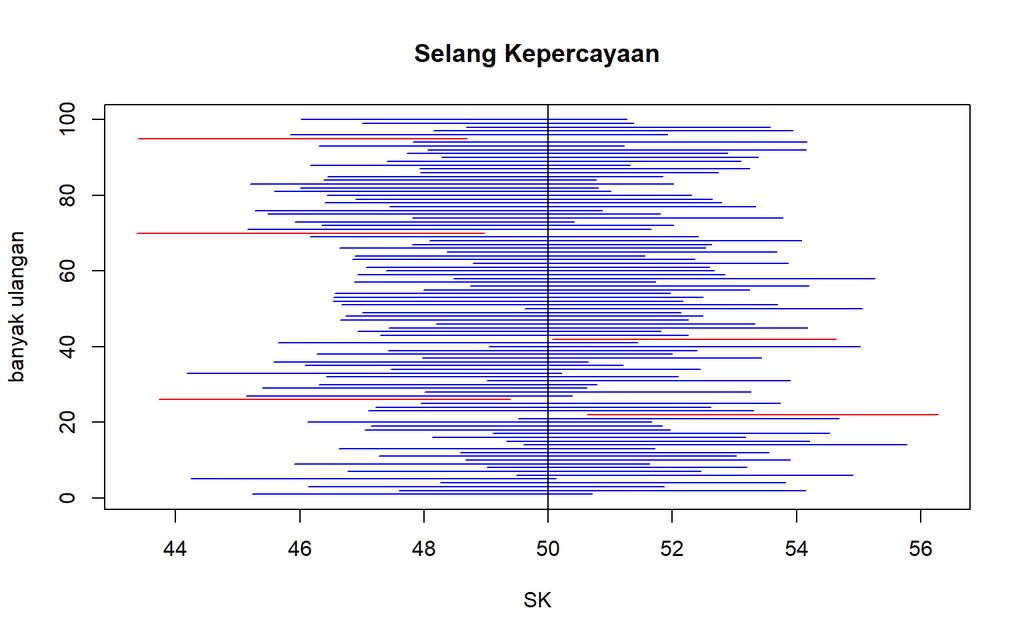

```r
matplot(rbind (xbar-z*SE, xbar+z*SE), rbind(1:k,1:k), col=ifelse(SK,"blue","red"), type = "l", lty = 1,main='Selang Kepercayaan', xlab='SK', ylab='banyak ulangan')
abline(v=mu)
```

# Latihan Praktikum

**Kelompok Ganjil**

1. Lakukan simulasi untuk membuktikan bahwa penduga mean $(λ)$ dan penduga varian dari sebaran Poisson merupakan penduga Tak Bias (note: Distribusi Poisson memiliki satu parameter, yaitu $λ$, yang mewakili rata-rata dan varians distribusi)
2. Lakukan simulasi untuk membuktikan bahwa $b_{0}$ dan $b_{1}$ merupakan penduga tak bias bagi $\beta _{0}$ dan $\beta _{1}$
3. Lakukan simulasi untuk selang kepercayaan 90%

**Kelompok Genap**

1. Lakukan simulasi untuk membuktikan bahwa penduga mean dan penduga varian dari sebaran seragam (uniform) merupakan penduga Tak Bias
2. Lakukan simulasi untuk membuktikan bahwa $b_{0}$ dan $b_{1}$ merupakan penduga tak bias bagi $\beta _{0}$ dan $\beta _{1}$
3. Lakukan simulai untuk selang kepercayaan 99%